# Monte Carlo Methods in Psychophysics

Simon Barthelmé, CNRS, Gipsa-lab (Grenoble)

November 2, 2015

# Monte Carlo Methods in Psychophysics

- Monte Carlo Methods: all mathematical methods that use random numbers.
- In psychophysics
- Used to simulate data from models (day I)
- Used to generate stimuli (day II)

# What’s a model?

- A model is just a recipe for generating data
- In neuroscience there’s a perception that you have
- on the one hand, data analysis methods that everybody uses
- on the other, proper “models”, that only the mathematically sophisticated use
- This is a myth. All the data analysis methods are based on models:
- A psychometric function is a model (and a threshold is a parameter estimate)
- Signal Detection Theory is a model (and d’ is a parameter estimate)
- Even an ANOVA is a model

# The bad news

- To really understand your data analysis techniques, you need to understand the underlying models
- You need to be clear on the role of randomness in the model

# The good news

- Implementing simple Monte Carlo methods can really help understand what’s going on
- Statistical methods in psychophysics involve very basic models, which are often building blocks in more sophisticated “proper models”.
- Today, we learn how to simulate a linear observer model with stimulus uncertainty in 4 lines of code

# Why would we want to simulate from a model?

- To understand the model
- To test your experimental procedures
- To test your statistical procedures
- To evaluate the uncertainty in your parameter estimates

# A first concrete example: Signal Detection Theory

# The same thing in compact notation

$z_i | x_i \sim N( d' x_i, 1)$ $y_i = sign( z_i - \beta )$

# How to simulate the behaviour of an observer

```r
run.trial <- function(x,dprime=1,beta=dprime/2)
    {
        z <- rnorm(1,mean=x*dprime,sd=1)
        y <- sign(z-beta)
        y
    }
```

# Line by line (1)

```
z <- rnorm(1,mean=x*dprime,sd=1)
```

generates a random value with a Gaussian distribution, mean x*dprime and standard dev. 1. That’s the noisy decision variable.

# Line by line (2)

```
y <- sign(z-beta)
```

gives us the sign of z-beta (-1 if z < beta, +1 otherwise). That’s the observer’s response.

# Output

```r
run.trial(1) #Signal trial
```

```
## [1] 1
```

```r
run.trial(0) #Noise trial
```

```
## [1] -1
```

```r
run.trial(0) #Another noise trial
```

```
## [1] -1
```

# Repeated trials

```r
replicate(10,run.trial(1)) #Ten signal trials
```

```
##  [1]  1  1 -1  1  1  1  1  1  1  1
```

```r
replicate(10,run.trial(0)) #Ten noise trials
```

```
##  [1] -1 -1 -1 -1  1 -1 -1  1 -1 -1
```

# Computing statistics

How often does the observer detect the stimulus? (hit rate)

```r
y.sig <- replicate(100,run.trial(1))
mean(y.sig == 1)
```

```
## [1] 0.71
```

How often does the observer falsely detect a stimulus? (FA rate)

```r
y.noi <- replicate(100,run.trial(0))
mean(y.noi == 1)
```

```
## [1] 0.4
```

# Monte Carlo error

The quantities we are computing aren’t deterministic:

```r
y.noi <- replicate(100,run.trial(0))
mean(y.noi == 1)
```

```
## [1] 0.27
```

```r
y.noi <- replicate(100,run.trial(0))
mean(y.noi == 1)
```

```
## [1] 0.29
```

so if we’re trying to estimate the theoretical FA rate from a finite sample we incur *Monte Carlo error*.

# Monte Carlo error vs. estimation error

The Monte Carlo error is the same as the estimation error we incur when inferring parameters from true data *if we assume data come exactly from our model*.

# Estimating estimation error

For example, here’s the theoretical estimation error we’d get for estimating FA rate for our observer from 20 trials:

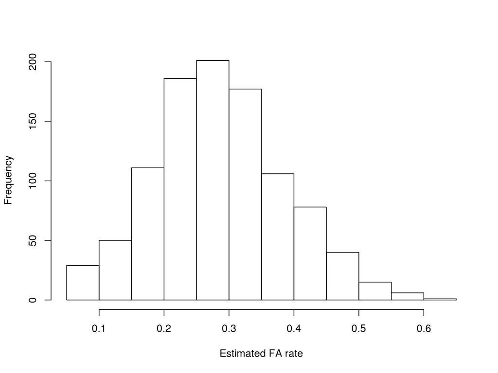

```r
est.fa <- function()
    {
        y.noi <- replicate(20,run.trial(0))
        mean(y.noi==1)
    }
fas <- replicate(1000,est.fa())
hist(fas,xlab="Estimated FA rate",main="")
```

# Estimating estimation error for d’

d’ is how the model quantifies discriminability. It’s usually estimated via the well-known formula:

```r
dprime <- function(fa,hr)
    {
        qnorm(hr)-qnorm(fa)
    }
```

# Variability in estimated d’

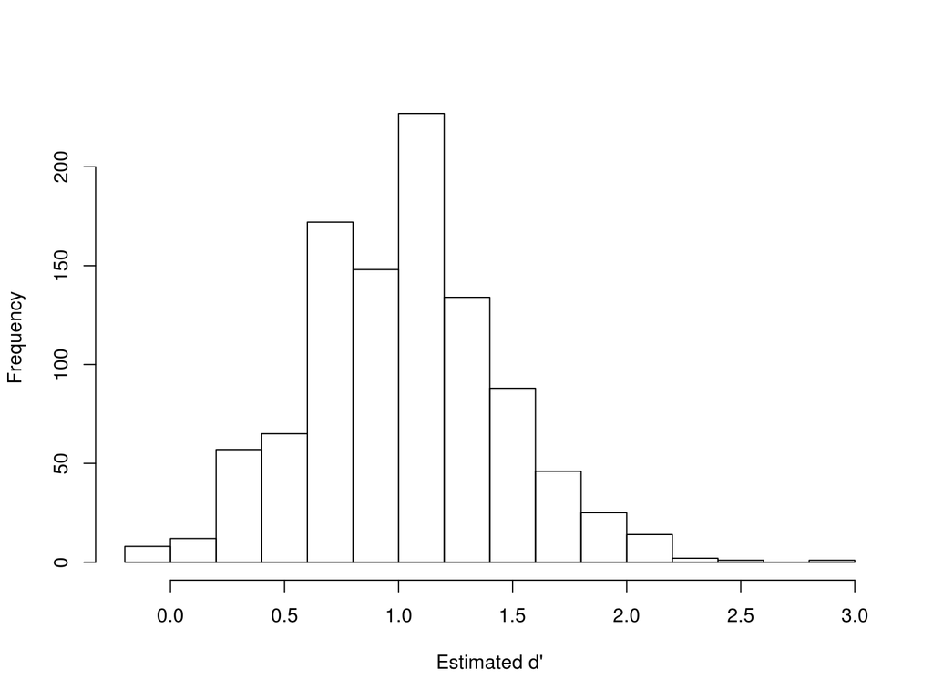

```r
est.dprime <- function() {
y.noi <- replicate(20,run.trial(0))
y.sig <- replicate(20,run.trial(1))
dprime(mean(y.noi==1),mean(y.sig==1))
}

dps <- replicate(1000,est.dprime())
hist(dps,main="",xlab="Estimated d'")
```

# FA rate as a function of threshold

Now we can take our model observer and vary some parameters to see what happens:

```r
fa.beta <- function(beta) {
y.noi <- replicate(100,run.trial(0,beta=beta))
mean(y.noi==1)
}

fa.beta(1)
```

```
## [1] 0.17
```

```r
fa.beta(-.1)
```

```
## [1] 0.54
```

# FA rate as a function of threshold

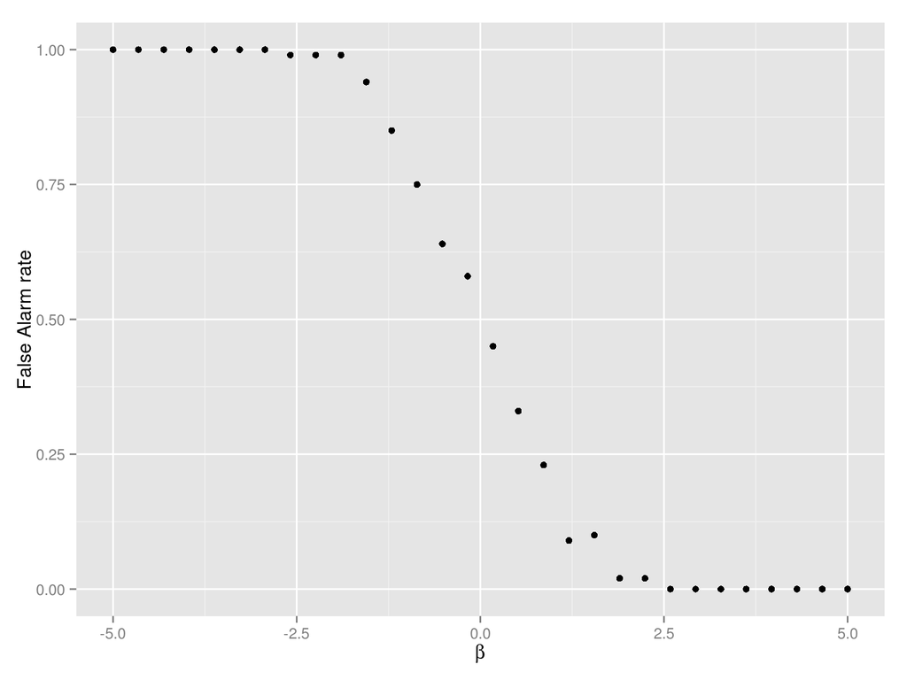

```r
betas <- seq(-5,5,l=30)
dat <- ldply(betas,function(b) data.frame(FA=fa.beta(b),beta=b))
p <- ggplot(dat,aes(beta,FA))+geom_point()+labs(x=expression(beta),y="False Alarm rate")
print(p)
```